# Other Data Sources

So far in this course you’ve worked with data that we had already prepared for you. It turns out that there are many R packages and tools that you can use to get data from a variety of different sources. Below, we will provide a brief walkthrough of just a few of these resources.

### `Lahman`

The [Lahman Baseball Database](http://www.seanlahman.com/baseball-archive/statistics/) is a popular resource created by Sean Lahman with historical data going back to 1871. Rather than having to access the database directly via complicated computing procedures, there is an R package we can install to access the data instead. The following code installs the package from the CRAN:

```r
install.packages("Lahman")
```

Next we load the package, and check out what datasets are available:

```r
library(Lahman)
```

```r
data(package = "Lahman")
```

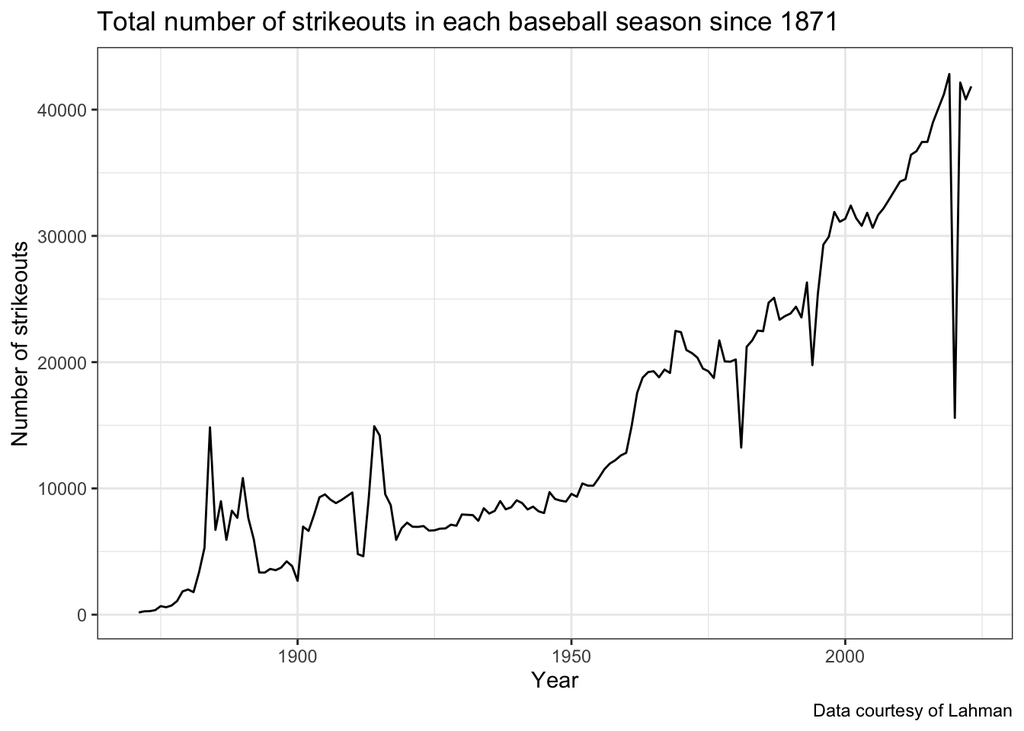

```r
Teams %>%
  group_by(yearID) %>%
  reframe(n_so = sum(SO, na.rm = TRUE)) %>%
  ggplot() +
  geom_line(aes(x = yearID, y = n_so)) +
  labs(x = "Year", y = "Number of strikeouts",
       title = "Total number of strikeouts in each baseball season since 1871",
       caption = "Data courtesy of Lahman") +
  theme_bw()
```

Note that rather than supplying the data as an argument to the `ggplot()` function, we can start with a dataset, make manipulations to it using pipes, and then pipe the new data into the `ggplot()` function.

We can see the increasing trend over time, but note some of the outliers like 2020 (pandemic-shortened season) and 1994 (strike-shortened season). How could this display be improved to handle these outliers, as well as the other gameplay-related changes that have taken place in baseball?

### `nflfastR`

The [`nflfastR` package](https://www.nflfastr.com/) gives R users the ability to scrape play-by-play data from the NFL in real-time during games, also providing expected points and win probability estimates. [Here’s a good tutorial](https://www.nflfastr.com/articles/nflfastR.html) on the main functions and data available within the package. To get started, we install the package below. Let’s also install the `ggimage` package, which will allow us to plot the team logos for more intriguing visualizations.

```r
install.packages("nflfastR")
install.packages("ggimage")
```

Next, we load these packages.

```r
library(nflfastR)
library(ggimage)
```

Now we can use `nflfastR` to gather play-by-play data for the 2021 season.

```r
pbp_2021 <- load_pbp(2021)
```

With this data, we can summarize the performance of all NFL teams using the expected points added (EPA) per game on offense and defense. EPA tells us how much value the team provided relative to an average baseline. The more positive the better the offensive performance. This means the more negative the value the defensive performance, so in the code chunk below we multiply the defensive values by -1 so it’s similar to offensive performance higher values meaning better performance. The following code uses this data to create offensive and defensive summaries that we will join together to plot:

```r
offense_epa_21 <- pbp_2021 %>%
  filter(!is.na(posteam)) %>%
  group_by(posteam) %>%
  summarise(n_games = length(unique(game_id)), off_total_epa = sum(epa, na.rm = TRUE)) %>%
  mutate(off_epa_per_game = off_total_epa / n_games)

defense_epa_21 <- pbp_2021 %>%
  filter(!is.na(defteam)) %>%
  group_by(defteam) %>%
  summarise(n_games = length(unique(game_id)), def_total_epa = sum(epa, na.rm = TRUE)) %>%
  # This time multiply by -1, since negative values are better for defense:
  mutate(def_epa_per_game = -1 * def_total_epa / n_games)
```

Next, we join together the offensive and defensive EPA datasets, then pass this new dataset into `ggplot`, where we make a plot of offensive EPA per game vs. defensive EPA per game for all teams in the 2021 season.

[figure not shown]

```r
# Create the data frame to be used for all of the charts:
offense_epa_21 %>%
  inner_join(defense_epa_21, by = c("posteam" = "defteam")) %>%
  left_join(teams_colors_logos, by = c("posteam" = "team_abbr")) %>%
  ggplot(aes(x = off_epa_per_game, y = def_epa_per_game)) +
  geom_image(aes(image = team_logo_espn), size = 0.05) +
  labs(x = "Offensive EPA per game",
       y = "Defensive EPA per game",
       caption = "Data accessed via nflfastR",
       title = "Offensive and defensive EPA per game for each team in the 2021 NFL season") +
  # Add reference lines at 0
  geom_hline(yintercept = 0, color = "red", linetype = "dashed") +
  geom_vline(xintercept = 0, color = "red", linetype = "dashed") +
  theme_bw()
```

The top right displays the teams that excelled at both offense and defense, while the lower right shows teams that had the best offenses such as the Chiefs but performed poorly on defense. The lower left shows the worst overall teams, where the Jags, Jets, and Texans unsurprisingly stand out.

## Installing GitHub Packages

While the vast majority of `R` packages you will commonly use are able to be installed using `install.packages()` because they are on the CRAN, there are a variety of popular `R` packages for accessing sports data that are currently only available through GitHub. In order to access these packages, we first need to install them using a package called `devtools`. The code below installs the `devtools` package:

```r
install.packages("devtools")
```

The `devtools` package has a function, `install_github` that we will use for installing the remaining packages used below.

Most of these resources are still in development, so installation and use can occasionally be inconsistent.

### `baseballr`

Created by [Bill Petti, the `baseballr` package](http://billpetti.github.io/baseballr/) has become a popular resource for accessing baseball data from variety of resources, such as[FanGraphs](https://www.fangraphs.com/) and [Baseball-Reference](https://www.baseball-reference.com/) directly into `R`. One of the best features of the `baseballr` package is the functionality it provides us for directly accessing the publicly available pitch-by-pitch and Statcast data available from [baseball-savant](https://baseballsavant.mlb.com/).

We first install the package using the `devtools` package explained above, and then load its functions:

```r
devtools::install_github("BillPetti/baseballr")
library(baseballr)
```

Using the `baseballr` package we can access all pitches thrown to a hitter in the current season, giving us Statcast data like exit velocity and launch angle. We first use the `playerid_lookup` function to find the Statcast ID for Yankees star (and potential AL MVP) Aaron Judge:

```r
playerid_lookup(last_name = "Judge", first_name = "Aaron")
```

This will load up a look-up table with all identifiers joining various sources together. It may take a couple minutes to run and may print warning messages. We find that Aaron Judge’s unique `mlbam_id` is 592450. Using this id, we can grab all pitches thrown to Judge in the current MLB season so far:

```r
judge_statcast_data <- scrape_statcast_savant_batter(start_date = "2022-01-01",
                                                    end_date = "2022-12-31",
                                                    batterid = 592450)
```

This dataset contains many columns; for now we will look at the relationship between the distance traveled of Aaron Judge’s batted balls (denoted by `type == "X"`) and the launch angle (`launch_angle`) as well as the exit velocity (`launch_speed`):

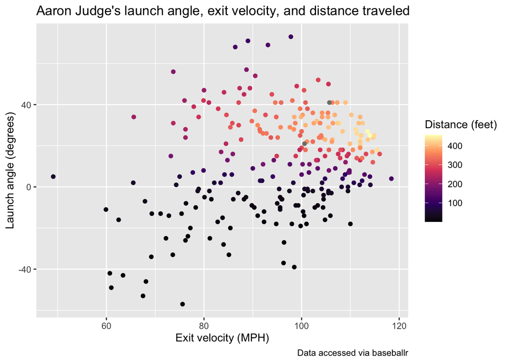

```r
judge_statcast_data %>%
  filter(type == "X") %>%
  ggplot(aes(x = launch_speed, y = launch_angle,
             color = hit_distance_sc)) +
  geom_point() +
  scale_color_viridis_c(option = "A") +
  labs(x = "Exit velocity (MPH)", y = "Launch angle (degrees)",
       color = "Distance (feet)",
       title = "Aaron Judge's launch angle, exit velocity, and distance traveled",
       caption = "Data accessed via baseballr")
```

*Note that this plot has been updated through July 15th of the 2022 season. Pitches thrown to Judge after this date will not appear on the above plot.*

This is just a single example of the type of data available using `baseballr`. See the package website for more [data acquisition functions](https://billpetti.github.io/baseballr/reference/index.html). Additionally, the [Exploring Baseball Data with R website by Jim Albert](https://baseballwithr.wordpress.com/) is an incredible resource with a variety of examples of learning R code all in the context of baseball data analysis.

### `nbastatr`

The [`nbastatr` package](http://asbcllc.com/nbastatR/) created by Alex Bresler is analogous to the `baseballr` package as it provides many different functions for accessing NBA data from a variety of websites. Again to be able to use the package you need to install it from GitHub:

```r
devtools::install_github("abresler/nbastatR")
library(nbastatR)
```

**There will likely be several messages that appear when installing this package, please let us know if you encounter any strange issues.** The code below demonstrates how to get all shot attempts by the 2022 NBA champions, the Golden State Warriors, in the past season using this package:

```r
warriors_shots <- teams_shots(teams = "Golden State Warriors",
                             seasons = c(2022))
```

Using this shot data, we can view the all shot attempts by the Warriors throughout the season colored by whether or not they made the shot.

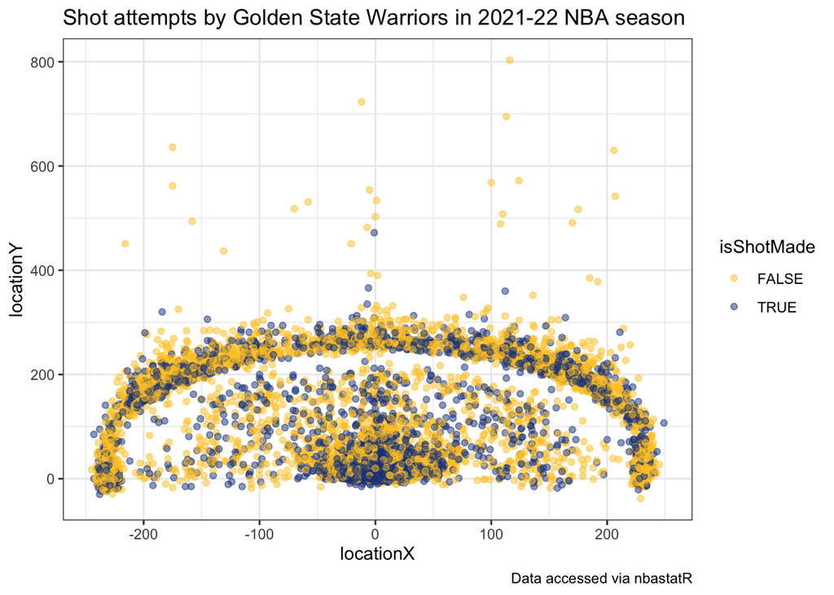

```r
warriors_shots %>%
  ggplot(aes(x = locationX, y = locationY, color = isShotMade)) +
  geom_point(alpha = 0.5) +
  scale_color_manual(values = c("#FFC72C", "#1D428A")) +
  theme_bw() +
  labs(title = "Shot attempts by Golden State Warriors in 2021-22 NBA season",
       caption = "Data accessed via nbastatR")
```

It’s apparent from this chart the effect of the three-point line of their shot selection.